# Deep Learning para la predicción de series temporales: Redes Neuronales Recurrentes (RNN) y Long Short-Term Memory (LSTM)

**Fernando Carazo Melo, Joaquín Amat Rodrigo**

*Enero, 2024 (última actualización Noviembre 2024)*

Más sobre forecasting en: [**cienciadedatos.net**](https://cienciadedatos.net)

- [Forecasting series temporales con machine learning](https://www.cienciadedatos.net/documentos/py27-forecasting-series-temporales-python-scikitlearn.html)
- [Modelos ARIMA y SARIMAX](https://cienciadedatos.net/documentos/py51-modelos-arima-sarimax-python.html)
- [Forecasting series temporales con gradient boosting: XGBoost, LightGBM y CatBoost](https://www.cienciadedatos.net/documentos/py39-forecasting-series-temporales-con-skforecast-xgboost-lightgbm-catboost.html)
- [Global Forecasting: Multi-series forecasting](https://www.cienciadedatos.net/documentos/py44-multi-series-forecasting-skforecast-espa%C3%B1ol.html)
- [Forecasting de la demanda eléctrica con machine learning](https://www.cienciadedatos.net/documentos/py29-forecasting-demanda-energia-electrica-python.html)
- [Forecasting con deep learning](https://cienciadedatos.net/documentos/py54-forecasting-con-deep-learning)
- [Forecasting de visitas a página web con machine learning](https://www.cienciadedatos.net/documentos/py37-forecasting-visitas-web-machine-learning.html)
- [Forecasting del precio de Bitcoin](https://www.cienciadedatos.net/documentos/py41-forecasting-criptomoneda-bitcoin-machine-learning-python.html)
- [Forecasting probabilístico](https://cienciadedatos.net/documentos/py42-forecasting-probabilistico.html)
- [Forecasting de demanda intermitente](https://www.cienciadedatos.net/documentos/py48-forecasting-demanda-intermitente.html)
- [Reducir el impacto del Covid en modelos de forecasting](https://www.cienciadedatos.net/documentos/py45-weighted-time-series-forecasting-es.html)
- [Modelar series temporales con tendencia utilizando modelos de árboles](https://www.cienciadedatos.net/documentos/py49-modelar-tendencia-en-series-temporales-modelos-de-arboles.html)

[figure not shown]

## Introdución

El *Deep Learning* es un campo de la inteligencia artificial enfocado en crear modelos basados en redes neuronales que permiten aprender representaciones no lineales de manera jerárquica. Las redes neuronales recurrentes (RNN) son un tipo de arquitectura de *deep learning* diseñada para trabajar con datos secuenciales, donde la información se propaga a través de conexiones recurrentes, permitiendo a la red aprender dependencias temporales.

Este artículo describe cómo entrenar modelos de *redes neuronales recurrentes* -específicamente RNN y LSTM- para la predicción de series temporales (*forecasting*) empleando **Python**, **Keras** y **Skforecast**.

- [**Keras3**](https://keras.io/keras_3/) proporciona una interfaz sencilla para construir y entrenar modelos de redes neuronales. Gracias a su API de alto nivel, los desarrolladores pueden implementar fácilmente arquitecturas LSTM, aprovechando las ventajas de la eficiencia computacional y la escalabilidad que ofrece el *deep learning*.
- [**Skforecast**](https://skforecast.org/) permite generalizar de forma sencilla la implementación y uso de modelos de machine learning -entre ellos LSTMs y RNNs- a problemas de forecasting. De esta forma, el usuario puede definir el problema y abstraerse de la arquitectura. Para usuarios avanzados, skforecast también permite ejecutar una arquitectura de *deep learning* previamente definida.

**✎ Nota**

Para comprender plenamente este artículo, se presupone cierto conocimiento sobre redes neuronales y deep learning. No obstante, si este no es el caso, y mientras trabajamos en la creación de nuevo material, te proporcionamos algunos enlaces de referencia para comenzar:

- [Introducción a redes neuronales con Python](https://cienciadedatos.net/documentos/py35-redes-neuronales-python)
- [Dive into Deep Learning](https://d2l.ai/)
- [An Introduction to Statistical Learning](https://www.statlearning.com/)

## Redes Neuronales Recurrentes (RNN)

Las Redes Neuronales Recurrentes (RNN) son un tipo de redes neuronales diseñadas para procesar datos que siguen un orden secuencial. En las redes neuronales convencionales, como las redes *feedforward*, la información fluye en una dirección, desde la entrada hasta la salida pasando por las capas ocultas, sin considerar la estructura secuencial de los datos. En cambio, las RNN mantienen estados internos o memorias, lo que les permite recordar información pasada y utilizarla para predecir datos futuros en la secuencia.

La unidad básica de una RNN es la célula recurrente. Esta célula toma dos entradas: la entrada actual y el estado oculto previo. El estado oculto puede entenderse como una "memoria" que retiene información de las iteraciones previas. La entrada actual y el estado oculto anterior se combinan para calcular la salida actual y el nuevo estado oculto. Esta salida se utiliza como entrada para la próxima iteración, junto con la siguiente entrada en la secuencia de datos.

A pesar de los avances que se han conseguido con las arquitecturas RNN, tienen limitaciones para capturar patrones a largo plazo. Es por esto que se han desarrollado variantes como las LSTM (Memorias a Corto y Largo Plazo) y las GRU (Unidades Recurrentes Gated), que abordan estos problemas y permiten retener información a largo plazo de manera más efectiva.

[figure not shown]

*Diagrama de una red RNN simple. Fuente: James, G., Witten, D., Hastie, T., & Tibshirani, R. (2013). An introduction to statistical learning (1st ed.) [PDF]. Springer.*

## Long Short-Term Memory (LSTM)

Las redes neuronales Long Short-Term Memory (LSTM) constituyen un tipo especializado de RNNs diseñadas para superar las limitaciones asociados con la captura de dependencias temporales a largo plazo. A diferencia de las RNN tradicionales, las LSTMs incorporan una arquitectura más compleja, introduciendo unidades de memoria y mecanismos de puertas para mejorar la gestión de la información a lo largo del tiempo.

**Estructura de las LSTMs**

Las LSTMs presentan una estructura modular que consta de tres puertas (*gates*) fundamentales: la puerta de olvido (*forget gate*), la puerta de entrada (*input gate*), y la puerta de salida (*output gate*). Estas puertas trabajan en conjunto para regular el flujo de información a través de la unidad de memoria, permitiendo un control más preciso sobre qué información retener y cuál olvidar.

- **Puerta de Olvido (*Forget Gate*):** Regula cuánta información se debe olvidar y cuánta se mantiene, combinando la entrada actual y la salida anterior mediante una función sigmoide.
- **Puerta de Entrada (*Input Gate*):** Decide cuánta nueva información debe añadirse a la memoria a largo plazo.
- **Puerta de Salida (Output Gate):** Determina cuánta información de la memoria actual se utilizará para la salida final, combinando la entrada actual y la información de la memoria mediante una función sigmoide.

[figure not shown]

*Diagrama de la entradas y dalidas de una LSTM. Fuente: codificandobits https://databasecamp.de/wp-content/uploads/lstm-architecture-1024x709.png.*

## Tipos de problemas en el modelado de series temporales

La complejidad de un problema de series temporarles suele estar definida por tres factores clave: primero, decidir qué serie o series temporales utilizar para entrenar el modelo; segundo, determinar qué o cuántas series temporales se quieren predecir; y tercero, definir el número de pasos a futuro que se desea predecir. Estos tres aspectos pueden ser un verdadero desafío al abordar problemas de series temporales.

Las redes neuronales recurrentes, gracias a su ámplia variedad de arquitecturas, permiten modelar los siguientes escenarios:

- **Problemas 1:1 - Modelar una única serie y predecir esa misma serie (single-serie, single-output)**
  - *Descripción:* Este tipo de problemas implica modelar una serie temporal utilizando únicamente su pasado. Es un problema típico autoregresivo.
  - *Ejemplo:* Predicción de la temperatura diaria en base a la temperatura de los últimos días.
- **Problemas N:1 - Modelar una única serie utilizando múltiples series (multi-series, single-output)**
  - *Descripción:* Se trata de problemas en los que se utilizan varias series temporales para predecir una única serie. Cada serie puede representar una entidad o variable diferente, pero la variable salida es solo una de las series.
  - *Ejemplo:* Predicción de la temperatura diaria en base a múltiples series como: temperatura, humedad y presión atmosférica.
- **Problemas N:M - Modelar múltiples series utilizando múltiples series (multi-series, multiple-outputs)**
  - *Descripción:* Estos problemas consisten en modelar y predecir valores futuros de varias series temporales al mismo tiempo.
  - *Ejemplo:* Pronosticar los valores en bolsa de varias acciones en función del histórico de la bolsa, del precio de la energía y materias primas.

En todos estos encenarios, la predicción puede realizarse *single-step forecasting* (un paso a futuro) o *multi-step forecasting* (múltiples pasos a futuro). En el primer caso, el modelo solo predice un único valor, mientras que en el segundo, el modelo predice múltiples valores a futuro.

En algunas situaciones, puede resultar complicado definir y crear la arquitectura de *Deep Learning* adecuada para abordar un problema concreto. La librería **skforecast** dispone de funcionalidades que permiten determinar la arquitectura de Tensorflow adecuada para cada problema, simplificando y acelerando el proceso de modelado para una amplia variedad de problemas. A continuación, se muestra un ejemplo de cómo utilizar skforecast para resolver cada uno de los problemas de series temporales descritos, utilizando redes neuronales recurrentes.

## Librerías

**💡 Tip: Configuración del backend**

Desde la versión `0.13.0` de Skforecast, se ha añadido soporte para el backend de PyTorch. Puedes configurar el backend exportando la variable de entorno `KERAS_BACKEND` o editando tu archivo de configuración local en `~/.keras/keras.json`. Las opciones de backend disponibles son: "tensorflow" y "torch". Ejemplo: ```python import os os.environ["KERAS_BACKEND"] = "torch" import keras ```

**⚠ Warning**

El backend debe configurarse antes de importar Keras, y no se puede cambiar el backend después de que se haya importado la librería.

```python
# Procesado de datos
# ==============================================================================
import os
import pandas as pd
import numpy as np
from skforecast.datasets import fetch_dataset

# Gráficos
# ==============================================================================
import matplotlib.pyplot as plt
from skforecast.plot import set_dark_theme
import plotly.express as px
import plotly.graph_objects as go
import plotly.io as pio
import plotly.offline as poff
pio.templates.default = "seaborn"
poff.init_notebook_mode(connected=True)

# Keras
# ==============================================================================
os.environ["KERAS_BACKEND"] = "tensorflow" # 'tensorflow', 'jax´ or 'torch'
import keras
from keras.optimizers import Adam
from keras.losses import MeanSquaredError
from keras.callbacks import EarlyStopping

if keras.__version__ > "3.0":
    if keras.backend.backend() == "tensorflow":
        import tensorflow
    elif keras.backend.backend() == "torch":
        import torch
    else:
        print("Backend not recognized. Please use 'tensorflow' or 'torch'.")

# Modelado
# ==============================================================================
import skforecast
from skforecast.deep_learning import ForecasterRnn
from skforecast.deep_learning.utils import create_and_compile_model
from sklearn.preprocessing import MinMaxScaler
from skforecast.model_selection import TimeSeriesFold
from skforecast.model_selection import backtesting_forecaster_multiseries

# Configuración warnings
# ==============================================================================
import warnings
warnings.filterwarnings('once')

color = '\033[1m\033[38;5;208m'
print(f"{color}Version skforecast: {skforecast.__version__}")
print(f"{color}Version Keras: {keras.__version__}")
print(f"{color}Using backend: {keras.backend.backend()}")
print(f"{color}Version pandas: {pd.__version__}")
print(f"{color}Version numpy: {np.__version__}")
if keras.__version__ > "3.0":
    if keras.backend.backend() == "tensorflow":
        print(f"{color}Version tensorflow: {tensorflow.__version__}")
    elif keras.backend.backend() == "torch":
        print(f"{color}Version torch: {torch.__version__}")
    else:
        print(f"{color}Version torch: {jax.__version__}")
```

```
Version skforecast: 0.14.0
Version Keras: 3.5.0
Using backend: tensorflow
Version pandas: 2.2.3
Version numpy: 1.26.4
Version tensorflow: 2.16.2
```

**⚠ Warning**

En el momento de escribir este documento, `tensorflow` solo es compatible con versiones de `numpy` inferiores a 2.0. Si tienes una versión superior, puedes reducirla ejecutando el siguiente comando: `pip install numpy==1.26.4`

```python
# Descarga y procesado de datos
# ==============================================================================
air_quality = fetch_dataset(name="air_quality_valencia_no_missing")
air_quality.head()
```

```
air_quality_valencia_no_missing
-------------------------------
Hourly measures of several air chemical pollutant at Valencia city (Avd.
Francia) from 2019-01-01 to 20213-12-31. Including the following variables:
pm2.5 (µg/m³), CO (mg/m³), NO (µg/m³), NO2 (µg/m³), PM10 (µg/m³), NOx (µg/m³),
O3 (µg/m³), Veloc. (m/s), Direc. (degrees), SO2 (µg/m³). Missing values have
been imputed using linear interpolation.
Red de Vigilancia y Control de la Contaminación Atmosférica, 46250047-València -
Av. França, https://mediambient.gva.es/es/web/calidad-ambiental/datos-
historicos.
Shape of the dataset: (43824, 10)
```

| datetime | so2 | co | no | no2 | pm10 | nox | o3 | veloc. | direc. | pm2.5 |
| --- | --- | --- | --- | --- | --- | --- | --- | --- | --- | --- |
| 2019-01-01 00:00:00 | 8.0 | 0.2 | 3.0 | 36.0 | 22.0 | 40.0 | 16.0 | 0.5 | 262.0 | 19.0 |
| 2019-01-01 01:00:00 | 8.0 | 0.1 | 2.0 | 40.0 | 32.0 | 44.0 | 6.0 | 0.6 | 248.0 | 26.0 |
| 2019-01-01 02:00:00 | 8.0 | 0.1 | 11.0 | 42.0 | 36.0 | 58.0 | 3.0 | 0.3 | 224.0 | 31.0 |
| 2019-01-01 03:00:00 | 10.0 | 0.1 | 15.0 | 41.0 | 35.0 | 63.0 | 3.0 | 0.2 | 220.0 | 30.0 |
| 2019-01-01 04:00:00 | 11.0 | 0.1 | 16.0 | 39.0 | 36.0 | 63.0 | 3.0 | 0.4 | 221.0 | 30.0 |

Se verifica que el conjunto de datos tiene un índice de tipo `DatetimeIndex` con frecuencia horaria. Si bien no es necesario que los datos tengan este tipo de índice para utilizar skforecast, es más ventajoso para el posterior uso de las predicciones.

```python
# Comprobación de índice y frecuencia
# ==============================================================================
print(f"Tipo de índice: {air_quality.index.dtype}")
print(f"Frecuencia: {air_quality.index.freq}")
```

```
Tipo de índice: datetime64[ns]
Frecuencia: <Hour>
```

Para facilitar el entrenamiento de los modelos, la búsqueda de hiperparámetros óptimos y la evaluación de su capacidad predictiva, los datos se dividen en tres conjuntos separados: entrenamiento, validación y test.

```python
# Split train-validation-test
# ==============================================================================
air_quality = air_quality.loc[:'2021-12-31 23:00:00', :].copy()
end_train = "2021-03-31 23:59:00"
end_validation = "2021-09-30 23:59:00"
air_quality_train = air_quality.loc[:end_train, :].copy()
air_quality_val = air_quality.loc[end_train:end_validation, :].copy()
air_quality_test = air_quality.loc[end_validation:, :].copy()

print(
    f"Fechas train      : {air_quality_train.index.min()} --- "
    f"{air_quality_train.index.max()}  (n={len(air_quality_train)})"
)
print(
    f"Fechas validation : {air_quality_val.index.min()} --- "
    f"{air_quality_val.index.max()}  (n={len(air_quality_val)})"
)
print(
    f"Fechas test       : {air_quality_test.index.min()} --- "
    f"{air_quality_test.index.max()}  (n={len(air_quality_test)})"
)
```

```
Fechas train      : 2019-01-01 00:00:00 --- 2021-03-31 23:00:00  (n=19704)
Fechas validation : 2021-04-01 00:00:00 --- 2021-09-30 23:00:00  (n=4392)
Fechas test       : 2021-10-01 00:00:00 --- 2021-12-31 23:00:00  (n=2208)
```

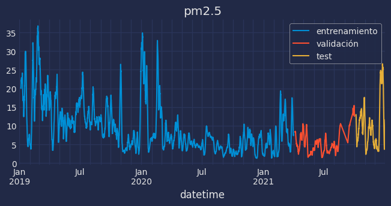

```python
# Gráfico de la serie temporal del contaminante pm2.5
# ==============================================================================
set_dark_theme()
fig, ax = plt.subplots(figsize=(7, 3))
air_quality_train["pm2.5"].rolling(100).mean().plot(ax=ax, label="entrenamiento")
air_quality_val["pm2.5"].rolling(100).mean().plot(ax=ax, label="validación")
air_quality_test["pm2.5"].rolling(100).mean().plot(ax=ax, label="test")
ax.set_title("pm2.5")
ax.legend();
```

## Modelo LSTM y ForecasterRnn

Si bien tensorflow-keras facilita el proceso de crear arquitecturas de *deep learning*, no siempre es trivial determinar las dimensiones que debe tener un modelo LSTM para forecasting ya que estas dependen de cuantas series temporales se estén modelando, cuantas prediciendo y la longitud del horicento de predicción.

Para tratar de mejorar la experiencia del usuario y acelerar el proceso de propotipado, desarollo y puesta en producción, skforecast dispone de la función `create_and_compile_model`, con la que, indicando apenas unos pocos argumentos, se infiere la arquitectura y se crea el modelo.

- `series`: Series temporales que se utilizarán para entrenar el modelo
- `levels`: Series temporales que se quieren predecir
- `lags`: Número de pasos de tiempo que se utilizarán para predecir el siguiente valor.
- `steps`: Número de pasos de tiempo que se quieren predecir.
- `recurrent_layer`: Tipo de capa recurrente a utilizar. Por defecto, se utiliza una capa LSTM.
- `recurrent_units`: Número de unidades de la capa recurrente. Por defecto, se utiliza 100. Si se pasa una lista, se creará una capa recurrente por cada elemento de la lista.
- `dense_units`: Número de unidades de la capa densa. Por defecto, se utiliza 64. Si se pasa una lista, se creará una capa densa por cada elemento de la lista.
- `optimizer`: Optimizador a utilizar. Por defecto, se utiliza Adam con learning rate de 0.01.
- `loss`: Función de pérdida a utilizar. Por defecto, se utiliza Mean Squared Error.

**✎ Nota**

La función `create_and_compile_model` está pensada para facilitar la creación del modelo Tensorflow, sin embargo, usuarios más avanzados pueden crear sus propias arquitecturas siempre y cuado las dimensiones de entrada y salida coincidan con el caso de uso al que se va a aplicar el modelo.

Una vez que el modelo se ha creado y compilado, el siguiente paso es crear una instancia del [ForecasterRnn](https://skforecast.org/latest/api/forecasterrnn). Esta clase se encarga de añadir al modelo de *deep learning* todas las funcionalidades necesarias para que pueda utilizarse en problemas de forecasting. Además es compatible con el resto de funcionalidades que ofrece skforecast (backtesting, busqueda de hiperparámetros, ...).

## Problema 1:1 - Modelar una única serie

En primer lugar, se realiza un pronóstico de un solo paso a futuro. Par ello, se creará un modelo utilizando la función `create_and_compile_model`, que se pasa como argumento a la clase `ForecasterRnn`.

Este es el ejemplo más sencillo de forecasting con redes neuronales recurrentes. El modelo solo necesita una serie temporal para entrenar y predecir. Por lo tanto, el argumento `series` de la función `create_and_compile_model` solo necesita una serie temporal, la mismo que se quiere predecir (`levels`). Además, como solo se quiere predecir un único valor a futuro, el argumento `steps` es igual a 1.

```python
# Creación del modelo
# ==============================================================================
series = ["o3"]  # Series temporales que se utilizarán para entrenar el modelo.
levels = ["o3"]  # Serie que se quiere predecir
lags = 32        # Valores pasados a utilizar en la predicción
steps = 1        # Pasos a futuro a predecir

# Selección de las series temporales utilizadas
data = air_quality[series].copy()
data_train = air_quality_train[series].copy()
data_val = air_quality_val[series].copy()
data_test = air_quality_test[series].copy()

model = create_and_compile_model(
    series=data_train,
    levels=levels,
    lags=lags,
    steps=steps,
    recurrent_layer="LSTM",
    recurrent_units=4,
    dense_units=16,
    optimizer=Adam(learning_rate=0.01),
    loss=MeanSquaredError()
)
model.summary()
```

```
keras version: 3.5.0
Using backend: tensorflow
tensorflow version: 2.16.2
```

```
Model: "functional"
```

```
┏━━━━━━━━━━━━━━━━━━━━━━━━━━━━━━━━━┳━━━━━━━━━━━━━━━━━━━━━━━━┳━━━━━━━━━━━━━━━┓
┃ Layer (type)                    ┃ Output Shape           ┃       Param # ┃
┡━━━━━━━━━━━━━━━━━━━━━━━━━━━━━━━━━╇━━━━━━━━━━━━━━━━━━━━━━━━╇━━━━━━━━━━━━━━━┩
│ input_layer (InputLayer)        │ (None, 32, 1)          │             0 │
├─────────────────────────────────┼────────────────────────┼───────────────┤
│ lstm (LSTM)                     │ (None, 4)              │            96 │
├─────────────────────────────────┼────────────────────────┼───────────────┤
│ dense (Dense)                   │ (None, 16)             │            80 │
├─────────────────────────────────┼────────────────────────┼───────────────┤
│ dense_1 (Dense)                 │ (None, 1)              │            17 │
├─────────────────────────────────┼────────────────────────┼───────────────┤
│ reshape (Reshape)               │ (None, 1, 1)           │             0 │
└─────────────────────────────────┴────────────────────────┴───────────────┘
```

```
 Total params: 193 (772.00 B)
```

```
 Trainable params: 193 (772.00 B)
```

```
 Non-trainable params: 0 (0.00 B)
```

Se utilizará un modelo sencillo, una red LSTM con una única capa recurrente con 4 neuronas y una capa oculta densa de 16 neuronas. La siguiente tabla muestra una descripción detallada de cada capa:

[output not shown]

Una vez que el modelo se ha creado y compilado, el siguiente paso es crear una instancia del ForecasterRnn. Esta clase se encarga de añadir al modelo de regresión todas las funcionalidades necesarias para que pueda utilizarse en problemas de forecasting. Además es compatible con el resto de funcionalidades que ofrece skforecast.

El forecaster se crea a partir del modelo y se le pasan los datos de validación para que pueda evaluar el modelo en cada época. Además, se le pasa un objeto `MinMaxScaler` para que estandarice los datos de entrada y salida. Este objeto se encargará de escalar los datos de entrada y de desescalar las predicciones.

Por otro lado, los `fit_kwargs` son los argumentos que se le pasan al método `fit` del modelo. En este caso, se le pasa el número de épocas, el tamaño del *batch*, los datos de validación y un *callback* para detener el entrenamiento cuando la pérdida de validación deje de disminuir.

```python
# Creación del forecaster
# ==============================================================================
forecaster = ForecasterRnn(
    regressor=model,
    levels=levels,
    transformer_series=MinMaxScaler(),
    fit_kwargs={
        "epochs": 10,      # Número de épocas para entrenar el modelo.
        "batch_size": 32,  # Tamaño del batch para entrenar el modelo.
        "callbacks": [
            EarlyStopping(monitor="val_loss", patience=5)
        ],  # Callback para detener el entrenamiento cuando ya no esté aprendiendo más.
        "series_val": data_val,  # Datos de validación para el entrenamiento del modelo.
    },
)
forecaster
```

```
/home/ubuntu/anaconda3/envs/skforecast_14_py12/lib/python3.12/site-packages/skforecast/deep_learning/_forecaster_rnn.py:229: UserWarning:

Setting `lags` = 'auto'. `lags` are inferred from the regressor architecture. Avoid the warning with lags=lags.

/home/ubuntu/anaconda3/envs/skforecast_14_py12/lib/python3.12/site-packages/skforecast/deep_learning/_forecaster_rnn.py:264: UserWarning:

`steps` default value = 'auto'. `steps` inferred from regressor architecture. Avoid the warning with steps=steps.
```

```
=============
ForecasterRnn
=============
Regressor: <Functional name=functional, built=True>
Lags: [ 1  2  3  4  5  6  7  8  9 10 11 12 13 14 15 16 17 18 19 20 21 22 23 24
 25 26 27 28 29 30 31 32]
Transformer for series: MinMaxScaler()
Window size: 32
Target series, levels: ['o3']
Multivariate series (names): None
Maximum steps predicted: [1]
Training range: None
Training index type: None
Training index frequency: None
Model parameters: {'name': 'functional', 'trainable': True, 'layers': [{'module': 'keras.layers', 'class_name': 'InputLayer', 'config': {'batch_shape': (None, 32, 1), 'dtype': 'float32', 'sparse': False, 'name': 'input_layer'}, 'registered_name': None, 'name': 'input_layer', 'inbound_nodes': []}, {'…
Compile parameters: {'optimizer': {'module': 'keras.optimizers', 'class_name': 'Adam', 'config': {'name': 'adam', 'learning_rate': 0.009999999776482582, 'weight_decay': None, 'clipnorm': None, 'global_clipnorm': None, 'clipvalue': None, 'use_ema': False, 'ema_momentum': 0.99, 'ema_overwrite_frequenc…
fit_kwargs: {'epochs': 10, 'batch_size': 32, 'callbacks': [<keras.src.callbacks.early_stopping.EarlyStopping object at 0x7f311f0ae960>]}
Creation date: 2024-11-10 19:15:05
Last fit date: None
Skforecast version: 0.14.0
Python version: 3.12.5
Forecaster id: None
```

**⚠ Warning**

```python
# Entrenamiento del forecaster
# ==============================================================================
forecaster.fit(data_train)
```

```
615/615 ━━━━━━━━━━━━━━━━━━━━ 8s 9ms/step - loss: 0.0153 - val_loss: 0.0059
615/615 ━━━━━━━━━━━━━━━━━━━━ 6s 9ms/step - loss: 0.0058 - val_loss: 0.0055
615/615 ━━━━━━━━━━━━━━━━━━━━ 6s 9ms/step - loss: 0.0055 - val_loss: 0.0066
615/615 ━━━━━━━━━━━━━━━━━━━━ 6s 9ms/step - loss: 0.0054 - val_loss: 0.0058
615/615 ━━━━━━━━━━━━━━━━━━━━ 6s 9ms/step - loss: 0.0054 - val_loss: 0.0054
615/615 ━━━━━━━━━━━━━━━━━━━━ 6s 9ms/step - loss: 0.0052 - val_loss: 0.0061
615/615 ━━━━━━━━━━━━━━━━━━━━ 6s 9ms/step - loss: 0.0053 - val_loss: 0.0055
615/615 ━━━━━━━━━━━━━━━━━━━━ 6s 9ms/step - loss: 0.0052 - val_loss: 0.0055
615/615 ━━━━━━━━━━━━━━━━━━━━ 6s 9ms/step - loss: 0.0052 - val_loss: 0.0057
615/615 ━━━━━━━━━━━━━━━━━━━━ 6s 9ms/step - loss: 0.0053 - val_loss: 0.0055
```

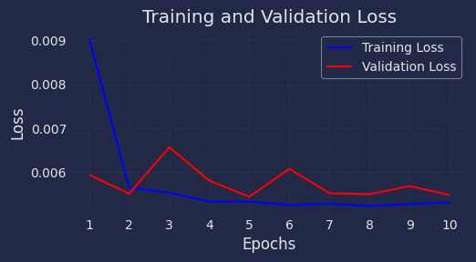

```python
# Seguimiento del entrenamiento y overfitting
# ==============================================================================
fig, ax = plt.subplots(figsize=(5, 2.5))
forecaster.plot_history(ax=ax)
```

En los modelos de *deep learning* es muy importante controlar el *overfitting*. Para ello, se utiliza un *callback* de Keras que detiene el entrenamiento cuando el valor de la función de coste, en los datos de validación, deja de disminuir. En este caso, el callback no llega a detener el entrenamiento, ya que únicamente hemos entrenado con 10 épocas. Si se aumenta el número de épocas, el callback detendrá el entrenamiento cuando la pérdida de validación deje de disminuir.

Por otro lado, otra herramienta muy util es el graficado de la pérdida de entrenamiento y validación en cada época. Esto permite visualizar el comportamiento del modelo y detectar posibles problemas de overfitting.

En el caso de nuestro modelo, se observa que la pérdida de entrenamiento disminuye rápidamente en las primera época, mientras que la pérdida de validación es baja desde la primera época. De esto se deduce lo siguiente:

- El modelo no está haciendo overfitting, ya que la pérdida de validación es similar a la de entrenamiento.
- El error de validación se calcula una vez se entrena el modelo, por ello el primer valor de la pérdida de validación en la primera época es parecido al de la pérdida de entrenamiento en la segunda época.

[figure not shown]

*Explicación gráfica del overfitting. Fuente: https://datahacker.rs/018-pytorch-popular-techniques-to-prevent-the-overfitting-in-a-neural-networks/.*

Una vez que el forecaster ha sido entrenado, se pueden obtener las predicciones. En este caso, es un único valor ya que solo se ha especificado un paso a futuro (`step`).

```python
# Predicción
# ==============================================================================
predictions = forecaster.predict()
predictions
```

|  | o3 |
| --- | --- |
| 2021-04-01 | 46.188419 |

Para obtener una estimación robusta de la capacidad predictiva del modelo, se realiza un proceso de [backtesting](https://skforecast.org/latest/user_guides/backtesting.html). El proceso de backtesting consiste en generar una predicción para cada observación del conjunto de test, siguiendo el mismo procedimiento que se seguiría si el modelo estuviese en producción, y finalmente comparar el valor predicho con el valor real.

```python
# Backtesting con datos de test
# ==============================================================================
cv = TimeSeriesFold(
    steps=forecaster.max_step,
    initial_train_size=len(data.loc[:end_validation, :]), # Datos de entrenamiento + validación
    refit=False,
)
metrics, predictions = backtesting_forecaster_multiseries(
    forecaster=forecaster,
    series=data,
    levels=forecaster.levels,
    cv=cv,
    metric="mean_absolute_error",
    verbose=False,
)
```

```
752/752 ━━━━━━━━━━━━━━━━━━━━ 6s 7ms/step - loss: 0.0052 - val_loss: 0.0053
752/752 ━━━━━━━━━━━━━━━━━━━━ 5s 7ms/step - loss: 0.0051 - val_loss: 0.0053
752/752 ━━━━━━━━━━━━━━━━━━━━ 5s 7ms/step - loss: 0.0051 - val_loss: 0.0052
752/752 ━━━━━━━━━━━━━━━━━━━━ 5s 7ms/step - loss: 0.0050 - val_loss: 0.0053
752/752 ━━━━━━━━━━━━━━━━━━━━ 5s 7ms/step - loss: 0.0051 - val_loss: 0.0054
752/752 ━━━━━━━━━━━━━━━━━━━━ 5s 7ms/step - loss: 0.0051 - val_loss: 0.0051
752/752 ━━━━━━━━━━━━━━━━━━━━ 5s 7ms/step - loss: 0.0049 - val_loss: 0.0053
752/752 ━━━━━━━━━━━━━━━━━━━━ 5s 7ms/step - loss: 0.0049 - val_loss: 0.0053
752/752 ━━━━━━━━━━━━━━━━━━━━ 5s 7ms/step - loss: 0.0051 - val_loss: 0.0052
752/752 ━━━━━━━━━━━━━━━━━━━━ 5s 7ms/step - loss: 0.0049 - val_loss: 0.0057
```

```python
# Predicciones de backtesting
# ==============================================================================
predictions
```

|  | o3 |
| --- | --- |
| 2021-10-01 00:00:00 | 47.974545 |
| 2021-10-01 01:00:00 | 53.241917 |
| 2021-10-01 02:00:00 | 57.280201 |
| 2021-10-01 03:00:00 | 58.263168 |
| 2021-10-01 04:00:00 | 48.706017 |
| ... | ... |
| 2021-12-31 19:00:00 | 11.269604 |
| 2021-12-31 20:00:00 | 11.328930 |
| 2021-12-31 21:00:00 | 12.406740 |
| 2021-12-31 22:00:00 | 12.487169 |
| 2021-12-31 23:00:00 | 13.279108 |

2208 rows × 1 columns

```python
# Gráfico de las predicciones vs valores reales en el conjunto de test
# ==============================================================================
fig = go.Figure()
trace1 = go.Scatter(x=data_test.index, y=data_test['o3'], name="test", mode="lines")
trace2 = go.Scatter(x=predictions.index, y=predictions['o3'], name="predicciones", mode="lines")
fig.add_trace(trace1)
fig.add_trace(trace2)
fig.update_layout(
    title="Predicciones vs valores reales en el conjunto de test",
    xaxis_title="Date time",
    yaxis_title="O3",
    width=750,
    height=350,
    margin=dict(l=20, r=20, t=35, b=20),
    legend=dict(
        orientation="h",
        yanchor="top",
        y=1.05,
        xanchor="left",
        x=0
    )
)
fig.show()
```

[interactive chart not shown]

```python
# Métricas de backtesting
# ==============================================================================
metrics
```

|  | levels | mean_absolute_error |
| --- | --- | --- |
| 0 | o3 | 6.287606 |

```python
# Error en % respecto a la media de la serie
# ==============================================================================
rel_mse = 100 * metrics.loc[0, 'mean_absolute_error'] / np.mean(data["o3"])
print(f"Media de la serie: {np.mean(data['o3']):0.2f}")
print(f"Error (mae) relativo: {rel_mse:0.2f} %")
```

```
Media de la serie: 54.52
Error (mae) relativo: 11.53 %
```

### Multi-step forecasting

En este caso, se desea predecir los próximos 5 valores de O3 utilizando únicamente sus datos históricos. Se trata por lo tanto de un escenario en el que múltiples pasos a futuro de una única serie temporal se modela utilizando únicamente sus valores pasados.

Para ello se utilizará una arquitectura similar a la anterior, pero con un mayor número de neuronas en la capa LSTM y en la primera capa densa. Esto permitirá al modelo tener mayor flexibilidad para modelar la serie temporal.

```python
# Creación del modelo
# ==============================================================================
series = ["o3"]  # Series temporales que se utilizarán para entrenar el modelo.
levels = ["o3"]  # Serie que se quiere predecir
lags = 32        # Valores pasados a utilizar en la predicción
steps = 5        # Pasos a futuro a predecir

model = create_and_compile_model(
    series=data_train,
    levels=levels,
    lags=lags,
    steps=steps,
    recurrent_layer="LSTM",
    recurrent_units=50,
    dense_units=32,
    optimizer=Adam(learning_rate=0.01),
    loss=MeanSquaredError()
)
model.summary()
```

```
keras version: 3.5.0
Using backend: tensorflow
tensorflow version: 2.16.2
```

```
Model: "functional_1"
```

```
┏━━━━━━━━━━━━━━━━━━━━━━━━━━━━━━━━━┳━━━━━━━━━━━━━━━━━━━━━━━━┳━━━━━━━━━━━━━━━┓
┃ Layer (type)                    ┃ Output Shape           ┃       Param # ┃
┡━━━━━━━━━━━━━━━━━━━━━━━━━━━━━━━━━╇━━━━━━━━━━━━━━━━━━━━━━━━╇━━━━━━━━━━━━━━━┩
│ input_layer_1 (InputLayer)      │ (None, 32, 1)          │             0 │
├─────────────────────────────────┼────────────────────────┼───────────────┤
│ lstm_1 (LSTM)                   │ (None, 50)             │        10,400 │
├─────────────────────────────────┼────────────────────────┼───────────────┤
│ dense_2 (Dense)                 │ (None, 32)             │         1,632 │
├─────────────────────────────────┼────────────────────────┼───────────────┤
│ dense_3 (Dense)                 │ (None, 5)              │           165 │
├─────────────────────────────────┼────────────────────────┼───────────────┤
│ reshape_1 (Reshape)             │ (None, 5, 1)           │             0 │
└─────────────────────────────────┴────────────────────────┴───────────────┘
```

```
 Total params: 12,197 (47.64 KB)
```

```
 Trainable params: 12,197 (47.64 KB)
```

```
 Non-trainable params: 0 (0.00 B)
```

```python
# Creación del Forecaster
# ==============================================================================
forecaster = ForecasterRnn(
    regressor=model,
    levels=levels,
    steps=steps,
    lags=lags,
    transformer_series=MinMaxScaler(),
    fit_kwargs={
        "epochs": 10,      # Número de épocas para entrenar el modelo.
        "batch_size": 32,  # Tamaño del batch para entrenar el modelo.
        "callbacks": [
            EarlyStopping(monitor="val_loss", patience=5)
        ],  # Callback para detener el entrenamiento cuando ya no esté aprendiendo más.
        "series_val": data_val,  # Datos de validación para el entrenamiento del modelo.
    },
)
```

**✎ Nota**

El parámetro `fit_kwargs` es de gran utilidad ya que permite establecer cualquier configuración en el modelo, en este caso de Keras. En el código anterior se define el número de épocas de entrenamiento (10) con un batch size de 32. Se configura un callback de `EarlyStopping` que detiene el entrenamiento cuando la pérdida de validación deja de disminuir durante 5 épocas (`patience=5`). También se pueden cofigurar otros callbacks como `ModelCheckpoint` para guardar el modelo en cada época, o incluso Tensorboard para visualizar la pérdida de entrenamiento y validación en tiempo real.

```python
# Entrenamiento del forecaster
# ==============================================================================
forecaster.fit(data_train)
```

```
615/615 ━━━━━━━━━━━━━━━━━━━━ 10s 13ms/step - loss: 0.0900 - val_loss: 0.0186
615/615 ━━━━━━━━━━━━━━━━━━━━ 8s 13ms/step - loss: 0.0173 - val_loss: 0.0171
615/615 ━━━━━━━━━━━━━━━━━━━━ 8s 13ms/step - loss: 0.0157 - val_loss: 0.0142
615/615 ━━━━━━━━━━━━━━━━━━━━ 8s 13ms/step - loss: 0.0152 - val_loss: 0.0141
615/615 ━━━━━━━━━━━━━━━━━━━━ 8s 13ms/step - loss: 0.0137 - val_loss: 0.0127
615/615 ━━━━━━━━━━━━━━━━━━━━ 8s 13ms/step - loss: 0.0130 - val_loss: 0.0116
615/615 ━━━━━━━━━━━━━━━━━━━━ 8s 13ms/step - loss: 0.0125 - val_loss: 0.0118
615/615 ━━━━━━━━━━━━━━━━━━━━ 8s 13ms/step - loss: 0.0125 - val_loss: 0.0139
615/615 ━━━━━━━━━━━━━━━━━━━━ 8s 13ms/step - loss: 0.0123 - val_loss: 0.0125
615/615 ━━━━━━━━━━━━━━━━━━━━ 8s 13ms/step - loss: 0.0119 - val_loss: 0.0125
```

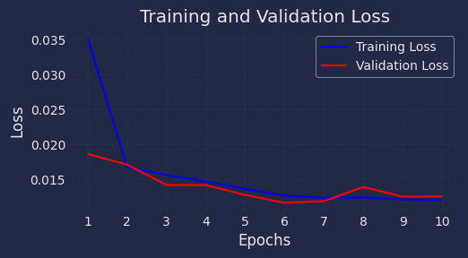

```python
# Seguimiento del entrenamiento y overfitting
# ==============================================================================
fig, ax = plt.subplots(figsize=(5, 2.5))
forecaster.plot_history(ax=ax)
```

Se intuye que la predicción va a ser de peor calidad que en el caso anterior, ya que el error observado en las distintas épocas es mayor. Esto tiene una explicación sencilla, y es que el modelo tiene que predecir 5 valores en lugar de 1. Por lo tanto, el error de validación es mayor ya que se está calculando la pérdida de 5 valores en lugar de 1.

Se realiza la predicción. En este caso son 5 valores ya que se ha especificado 5 pasos a futuro (`step`).

```python
# Predicción
# ==============================================================================
predictions = forecaster.predict()
predictions
```

|  | o3 |
| --- | --- |
| 2021-04-01 00:00:00 | 59.823212 |
| 2021-04-01 01:00:00 | 55.443535 |
| 2021-04-01 02:00:00 | 49.204967 |
| 2021-04-01 03:00:00 | 42.670982 |
| 2021-04-01 04:00:00 | 37.015419 |

También se pueden predecir `steps` especificos, siempre y cuando se encuentren dentro del horizonte de predicción definido en el modelo.

```python
# Predicción steps especificos
# ==============================================================================
predictions = forecaster.predict(steps=[1, 3])
predictions
```

|  | o3 |
| --- | --- |
| 2021-04-01 00:00:00 | 59.823212 |
| 2021-04-01 02:00:00 | 49.204967 |

```python
# Backtesting con datos de test
# ==============================================================================
cv = TimeSeriesFold(
    steps=forecaster.max_step,
    initial_train_size=len(data.loc[:end_validation, :]), # Datos de entrenamiento + validación
    refit=False,
)

metrics, predictions = backtesting_forecaster_multiseries(
    forecaster=forecaster,
    series=data,
    levels=forecaster.levels,
    cv=cv,
    metric="mean_absolute_error",
    verbose=False,
)
```

```
752/752 ━━━━━━━━━━━━━━━━━━━━ 11s 13ms/step - loss: 0.0121 - val_loss: 0.0124
752/752 ━━━━━━━━━━━━━━━━━━━━ 10s 13ms/step - loss: 0.0116 - val_loss: 0.0117
752/752 ━━━━━━━━━━━━━━━━━━━━ 10s 13ms/step - loss: 0.0118 - val_loss: 0.0128
752/752 ━━━━━━━━━━━━━━━━━━━━ 10s 13ms/step - loss: 0.0116 - val_loss: 0.0111
752/752 ━━━━━━━━━━━━━━━━━━━━ 10s 13ms/step - loss: 0.0114 - val_loss: 0.0130
752/752 ━━━━━━━━━━━━━━━━━━━━ 10s 13ms/step - loss: 0.0115 - val_loss: 0.0119
752/752 ━━━━━━━━━━━━━━━━━━━━ 10s 13ms/step - loss: 0.0114 - val_loss: 0.0115
752/752 ━━━━━━━━━━━━━━━━━━━━ 10s 13ms/step - loss: 0.0114 - val_loss: 0.0122
752/752 ━━━━━━━━━━━━━━━━━━━━ 10s 13ms/step - loss: 0.0113 - val_loss: 0.0109
752/752 ━━━━━━━━━━━━━━━━━━━━ 10s 13ms/step - loss: 0.0113 - val_loss: 0.0113
```

```python
# Predicciones de backtesting
# ==============================================================================
predictions
```

|  | o3 |
| --- | --- |
| 2021-10-01 00:00:00 | 54.473953 |
| 2021-10-01 01:00:00 | 55.619694 |
| 2021-10-01 02:00:00 | 53.802704 |
| 2021-10-01 03:00:00 | 48.287266 |
| 2021-10-01 04:00:00 | 44.964432 |
| ... | ... |
| 2021-12-31 19:00:00 | 19.735279 |
| 2021-12-31 20:00:00 | 18.135487 |
| 2021-12-31 21:00:00 | 11.726017 |
| 2021-12-31 22:00:00 | 14.964219 |
| 2021-12-31 23:00:00 | 18.540014 |

2208 rows × 1 columns

```python
# Gráfico de las predicciones vs valores reales en el conjunto de test
# ==============================================================================
fig = go.Figure()
trace1 = go.Scatter(x=data_test.index, y=data_test['o3'], name="test", mode="lines")
trace2 = go.Scatter(x=predictions.index, y=predictions['o3'], name="predicciones", mode="lines")
fig.add_trace(trace1)
fig.add_trace(trace2)
fig.update_layout(
    title="Predicciones vs valores reales en el conjunto de test",
    xaxis_title="Date time",
    yaxis_title="O3",
    width=750,
    height=350,
    margin=dict(l=20, r=20, t=35, b=20),
    legend=dict(
        orientation="h",
        yanchor="top",
        y=1.05,
        xanchor="left",
        x=0
    )
)
fig.show()
```

[interactive chart not shown]

```python
# Métricas de backtesting
# ==============================================================================
metrics
```

|  | levels | mean_absolute_error |
| --- | --- | --- |
| 0 | o3 | 9.354099 |

```python
# Error mse en % respecto a la media de la serie
# ==============================================================================
rel_mse = 100 * metrics.loc[0, 'mean_absolute_error'] / np.mean(data["o3"])
print(f"Media de la serie: {np.mean(data['o3']):0.2f}")
print(f"Error mse relativo: {rel_mse:0.2f} %")
```

```
Media de la serie: 54.52
Error mse relativo: 17.16 %
```

En este caso la predicción es empeora respecto al caso anterior. Esto es de esperar ya que el modelo tiene que predecir 5 valores en lugar de 1.

## Problemas N:1 - Series temporales múltiples con salida única

En este caso se tratará de predecir la misma serie temporal, pero utilizando múltiples series temporales como predictores. Se trata, por lo tanto, de un escenario en el que valores pasados de múltiples series temporales se utilizan predecir una única serie temporal.

Este tipo de aproximaciones son muy útiles cuando se dispone de múltiples series temporales relacionadas entre sí. Por ejemplo, en el caso de la predicción de la temperatura, se pueden utilizar múltiples series temporales como la humedad, la presión atmosférica, la velocidad del viento, etc.

En este tipo de problemas, la arquitectura de la red neuronal es más compleja, se necesita una capa densa recurrente adicional para procesar las múltiples series de entrada. Además, se añade otra capa oculta densa para procesar la salida de la capa recurrente. Como se puede observar, la creación del modelo utilizando `skforecast` es muy sencilla, simplemente basta con pasar una lista de enteros al arguento `recurrent_units` y `dense_units` para crear múltiples capas recurrentes y densas.

```python
# Creación del modelo
# ==============================================================================
# Series temporales utilizadas en el entrenamiento. Tiene que incluir la serie a predecir.
series = ['pm2.5', 'co', 'no', 'no2', 'pm10', 'nox', 'o3', 'veloc.', 'direc.','so2']
levels = ["o3"]  # Serie que se quiere predecir
lags = 32        # Valores pasados a utilizar en la predicción
steps = 5        # Pasos a futuro a predecir

# Selección de las series temporales utilizadas
data = air_quality[series].copy()
data_train = air_quality_train[series].copy()
data_val = air_quality_val[series].copy()
data_test = air_quality_test[series].copy()

model = create_and_compile_model(
    series=data_train,
    levels=levels,
    lags=lags,
    steps=steps,
    recurrent_layer="LSTM",
    recurrent_units=[100, 50],
    dense_units=[64, 32],
    optimizer=Adam(learning_rate=0.01),
    loss=MeanSquaredError()
)
model.summary()
```

```
keras version: 3.5.0
Using backend: tensorflow
tensorflow version: 2.16.2
```

```
Model: "functional_2"
```

```
┏━━━━━━━━━━━━━━━━━━━━━━━━━━━━━━━━━┳━━━━━━━━━━━━━━━━━━━━━━━━┳━━━━━━━━━━━━━━━┓
┃ Layer (type)                    ┃ Output Shape           ┃       Param # ┃
┡━━━━━━━━━━━━━━━━━━━━━━━━━━━━━━━━━╇━━━━━━━━━━━━━━━━━━━━━━━━╇━━━━━━━━━━━━━━━┩
│ input_layer_2 (InputLayer)      │ (None, 32, 10)         │             0 │
├─────────────────────────────────┼────────────────────────┼───────────────┤
│ lstm_2 (LSTM)                   │ (None, 32, 100)        │        44,400 │
├─────────────────────────────────┼────────────────────────┼───────────────┤
│ lstm_3 (LSTM)                   │ (None, 50)             │        30,200 │
├─────────────────────────────────┼────────────────────────┼───────────────┤
│ dense_4 (Dense)                 │ (None, 64)             │         3,264 │
├─────────────────────────────────┼────────────────────────┼───────────────┤
│ dense_5 (Dense)                 │ (None, 32)             │         2,080 │
├─────────────────────────────────┼────────────────────────┼───────────────┤
│ dense_6 (Dense)                 │ (None, 5)              │           165 │
├─────────────────────────────────┼────────────────────────┼───────────────┤
│ reshape_2 (Reshape)             │ (None, 5, 1)           │             0 │
└─────────────────────────────────┴────────────────────────┴───────────────┘
```

```
 Total params: 80,109 (312.93 KB)
```

```
 Trainable params: 80,109 (312.93 KB)
```

```
 Non-trainable params: 0 (0.00 B)
```

Una vez que el modelo se ha creado y compilado, el siguiente paso es crear una instancia del ForecasterRnn. Esta clase se encarga de añadir al modelo de regresión, todas las funcionalidades necesarias para que pueda utilizarse en problemas de forecasting.

```python
# Creación del Forecaster
# ==============================================================================
forecaster = ForecasterRnn(
    regressor=model,
    levels=levels,
    steps=steps,
    lags=lags,
    transformer_series=MinMaxScaler(),
    fit_kwargs={
        "epochs": 4,             # Número de épocas para entrenar el modelo.
        "batch_size": 128,       # Tamaño del batch para entrenar el modelo.
        "series_val": data_val,  # Datos de validación para el entrenamiento del modelo.
    },
)
forecaster
```

```
=============
ForecasterRnn
=============
Regressor: <Functional name=functional_2, built=True>
Lags: [ 1  2  3  4  5  6  7  8  9 10 11 12 13 14 15 16 17 18 19 20 21 22 23 24
 25 26 27 28 29 30 31 32]
Transformer for series: MinMaxScaler()
Window size: 32
Target series, levels: ['o3']
Multivariate series (names): None
Maximum steps predicted: [1 2 3 4 5]
Training range: None
Training index type: None
Training index frequency: None
Model parameters: {'name': 'functional_2', 'trainable': True, 'layers': [{'module': 'keras.layers', 'class_name': 'InputLayer', 'config': {'batch_shape': (None, 32, 10), 'dtype': 'float32', 'sparse': False, 'name': 'input_layer_2'}, 'registered_name': None, 'name': 'input_layer_2', 'inbound_nodes': …
Compile parameters: {'optimizer': {'module': 'keras.optimizers', 'class_name': 'Adam', 'config': {'name': 'adam', 'learning_rate': 0.009999999776482582, 'weight_decay': None, 'clipnorm': None, 'global_clipnorm': None, 'clipvalue': None, 'use_ema': False, 'ema_momentum': 0.99, 'ema_overwrite_frequenc…
fit_kwargs: {'epochs': 4, 'batch_size': 128}
Creation date: 2024-11-10 19:23:10
Last fit date: None
Skforecast version: 0.14.0
Python version: 3.12.5
Forecaster id: None
```

```python
# Entrenamiento del Modelo
# ==============================================================================
forecaster.fit(data_train)
```

```
154/154 ━━━━━━━━━━━━━━━━━━━━ 14s 69ms/step - loss: 0.0552 - val_loss: 0.0211
154/154 ━━━━━━━━━━━━━━━━━━━━ 10s 66ms/step - loss: 0.0160 - val_loss: 0.0130
154/154 ━━━━━━━━━━━━━━━━━━━━ 10s 66ms/step - loss: 0.0117 - val_loss: 0.0125
154/154 ━━━━━━━━━━━━━━━━━━━━ 10s 68ms/step - loss: 0.0105 - val_loss: 0.0135
```

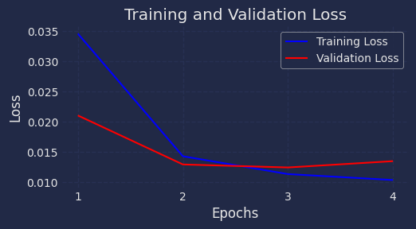

```python
# Seguimiento del entrenamiento y overfitting
# ==============================================================================
fig, ax = plt.subplots(figsize=(5, 2.5))
forecaster.plot_history(ax=ax)
```

```python
# Predicción
# ==============================================================================
predictions = forecaster.predict()
predictions
```

|  | o3 |
| --- | --- |
| 2021-04-01 00:00:00 | 45.171612 |
| 2021-04-01 01:00:00 | 44.146980 |
| 2021-04-01 02:00:00 | 39.552132 |
| 2021-04-01 03:00:00 | 33.851700 |
| 2021-04-01 04:00:00 | 30.631172 |

```python
# Backtesting con datos de test
# ==============================================================================
cv = TimeSeriesFold(
        steps=forecaster.max_step,
        initial_train_size=len(data.loc[:end_validation, :]), # Datos de entrenamiento + validación
        refit=False,
)
metrics, predictions = backtesting_forecaster_multiseries(
    forecaster=forecaster,
    series=data,
    levels=forecaster.levels,
    cv=cv,
    metric="mean_absolute_error",
    verbose=False,
)
```

```
188/188 ━━━━━━━━━━━━━━━━━━━━ 17s 77ms/step - loss: 0.0102 - val_loss: 0.0117
188/188 ━━━━━━━━━━━━━━━━━━━━ 14s 76ms/step - loss: 0.0101 - val_loss: 0.0109
188/188 ━━━━━━━━━━━━━━━━━━━━ 14s 76ms/step - loss: 0.0095 - val_loss: 0.0099
188/188 ━━━━━━━━━━━━━━━━━━━━ 14s 75ms/step - loss: 0.0095 - val_loss: 0.0120
```

```python
# Métricas de error de backtesting
# ==============================================================================
metrics
```

|  | levels | mean_absolute_error |
| --- | --- | --- |
| 0 | o3 | 10.0153 |

```python
# Error mse en % respecto a la media de la serie
# ==============================================================================
rel_mse = 100 * metrics.loc[0, 'mean_absolute_error'] / np.mean(data["o3"])
print(f"Media de la serie: {np.mean(data['o3']):0.2f}")
print(f"Error mse relativo: {rel_mse:0.2f} %")
```

```
Media de la serie: 54.52
Error mse relativo: 18.37 %
```

```python
# Predicciones de backtesting
# ==============================================================================
predictions
```

|  | o3 |
| --- | --- |
| 2021-10-01 00:00:00 | 50.596924 |
| 2021-10-01 01:00:00 | 49.763729 |
| 2021-10-01 02:00:00 | 45.184921 |
| 2021-10-01 03:00:00 | 41.663902 |
| 2021-10-01 04:00:00 | 37.941143 |
| ... | ... |
| 2021-12-31 19:00:00 | 9.503234 |
| 2021-12-31 20:00:00 | 3.620235 |
| 2021-12-31 21:00:00 | 0.667195 |
| 2021-12-31 22:00:00 | -4.080724 |
| 2021-12-31 23:00:00 | -3.693879 |

2208 rows × 1 columns

```python
# Gráfico de las predicciones vs valores reales en el conjunto de test
# ==============================================================================
fig = go.Figure()
trace1 = go.Scatter(x=data_test.index, y=data_test['o3'], name="test", mode="lines")
trace2 = go.Scatter(x=predictions.index, y=predictions['o3'], name="predicciones", mode="lines")
fig.add_trace(trace1)
fig.add_trace(trace2)
fig.update_layout(
    title="Predicciones vs valores reales en el conjunto de test",
    xaxis_title="Date time",
    yaxis_title="O3",
    width=750,
    height=350,
    margin=dict(l=20, r=20, t=35, b=20),
    legend=dict(
        orientation="h",
        yanchor="top",
        y=1.05,
        xanchor="left",
        x=0
    )
)
fig.show()
```

[interactive chart not shown]

Al utilizar múltiples series temporales como predictores cabría esperar que el modelo fuera capaz de predecir mejor la serie objetivo. Sin embargo, en este caso las predicciones son peores que en el caso anterior en el que solo se utilizaba una serie temporal como predictor. Esto puede deberse a que a que las series temporales utilizadas como predictores no están relacionadas con la serie objetivo. Por lo tanto, el modelo no es capaz de aprender ninguna relación entre ellas.

## Problemas N:M - Series temporales múltiples con salidas múltiples

El siguiente y último escenario, consiste en predecir múltiples series temporales utilizando múltiples series temporales como predictores. Se trata, por lo tanto, de un escenario en el que se modelan múltiples series simultaneamente utilizando un único modelo. Esto tiene especial aplicación en muchos escenarios reales, como por ejemplo, la predicción de valores en bolsa de varias empresas en función del histórico de la bolsa, del precio de la energía y materias primas. O el caso del forecasting de múltiples productos en una tienda online, en función de las ventas de otros productos, el precio de los productos, etc.

```python
# Creación del modelo
# ==============================================================================
series = ['pm2.5', 'co', 'no', 'no2', 'pm10', 'nox', 'o3', 'veloc.', 'direc.', 'so2']
levels = ['pm2.5', 'co', 'no', "o3"] # Características a predecir. Pueden ser todas las serires o menos
lags = 32 # Valores pasados a utilizar en la predicción
steps = 5 # Pasos a futuro a predecir

data = air_quality[series].copy()
data_train = air_quality_train[series].copy()
data_val = air_quality_val[series].copy()
data_test = air_quality_test[series].copy()

model = create_and_compile_model(
    series=data_train,
    levels=levels,
    lags=lags,
    steps=steps,
    recurrent_layer="LSTM",
    recurrent_units=[100, 50],
    dense_units=[64, 32],
    optimizer=Adam(learning_rate=0.01),
    loss=MeanSquaredError()
)
model.summary()
```

```
keras version: 3.5.0
Using backend: tensorflow
tensorflow version: 2.16.2
```

```
Model: "functional_3"
```

```
┏━━━━━━━━━━━━━━━━━━━━━━━━━━━━━━━━━┳━━━━━━━━━━━━━━━━━━━━━━━━┳━━━━━━━━━━━━━━━┓
┃ Layer (type)                    ┃ Output Shape           ┃       Param # ┃
┡━━━━━━━━━━━━━━━━━━━━━━━━━━━━━━━━━╇━━━━━━━━━━━━━━━━━━━━━━━━╇━━━━━━━━━━━━━━━┩
│ input_layer_3 (InputLayer)      │ (None, 32, 10)         │             0 │
├─────────────────────────────────┼────────────────────────┼───────────────┤
│ lstm_4 (LSTM)                   │ (None, 32, 100)        │        44,400 │
├─────────────────────────────────┼────────────────────────┼───────────────┤
│ lstm_5 (LSTM)                   │ (None, 50)             │        30,200 │
├─────────────────────────────────┼────────────────────────┼───────────────┤
│ dense_7 (Dense)                 │ (None, 64)             │         3,264 │
├─────────────────────────────────┼────────────────────────┼───────────────┤
│ dense_8 (Dense)                 │ (None, 32)             │         2,080 │
├─────────────────────────────────┼────────────────────────┼───────────────┤
│ dense_9 (Dense)                 │ (None, 20)             │           660 │
├─────────────────────────────────┼────────────────────────┼───────────────┤
│ reshape_3 (Reshape)             │ (None, 5, 4)           │             0 │
└─────────────────────────────────┴────────────────────────┴───────────────┘
```

```
 Total params: 80,604 (314.86 KB)
```

```
 Trainable params: 80,604 (314.86 KB)
```

```
 Non-trainable params: 0 (0.00 B)
```

```python
# Creación del forecaster
# ==============================================================================
forecaster = ForecasterRnn(
    regressor=model,
    levels=levels,
    steps=steps,
    lags=lags,
    transformer_series=MinMaxScaler(),
    fit_kwargs={
        "epochs": 100,      # Número de épocas para entrenar el modelo.
        "batch_size": 128,  # Tamaño del batch para entrenar el modelo.
        "callbacks": [
            EarlyStopping(monitor="val_loss", patience=5)
        ],  # Callback para detener el entrenamiento cuando ya no esté aprendiendo más.
        "series_val": data_val,  # Datos de validación para el entrenamiento del modelo.
    },
)
forecaster
```

```
=============
ForecasterRnn
=============
Regressor: <Functional name=functional_3, built=True>
Lags: [ 1  2  3  4  5  6  7  8  9 10 11 12 13 14 15 16 17 18 19 20 21 22 23 24
 25 26 27 28 29 30 31 32]
Transformer for series: MinMaxScaler()
Window size: 32
Target series, levels: ['pm2.5', 'co', 'no', 'o3']
Multivariate series (names): None
Maximum steps predicted: [1 2 3 4 5]
Training range: None
Training index type: None
Training index frequency: None
Model parameters: {'name': 'functional_3', 'trainable': True, 'layers': [{'module': 'keras.layers', 'class_name': 'InputLayer', 'config': {'batch_shape': (None, 32, 10), 'dtype': 'float32', 'sparse': False, 'name': 'input_layer_3'}, 'registered_name': None, 'name': 'input_layer_3', 'inbound_nodes': …
Compile parameters: {'optimizer': {'module': 'keras.optimizers', 'class_name': 'Adam', 'config': {'name': 'adam', 'learning_rate': 0.009999999776482582, 'weight_decay': None, 'clipnorm': None, 'global_clipnorm': None, 'clipvalue': None, 'use_ema': False, 'ema_momentum': 0.99, 'ema_overwrite_frequenc…
fit_kwargs: {'epochs': 100, 'batch_size': 128, 'callbacks': [<keras.src.callbacks.early_stopping.EarlyStopping object at 0x7f311a56fa40>]}
Creation date: 2024-11-10 19:25:48
Last fit date: None
Skforecast version: 0.14.0
Python version: 3.12.5
Forecaster id: None
```

Se entrena el modelo durante 100 épocas con un callback de `EarlyStopping` que detiene el entrenamiento cuando la pérdida de validación deja de disminuir durante 5 épocas (`patience=5`).

**⚠ Warning**

```python
# Entrenamiento del forecaster
# ==============================================================================
forecaster.fit(data_train)
```

```
154/154 ━━━━━━━━━━━━━━━━━━━━ 16s 79ms/step - loss: 0.0129 - val_loss: 0.0099
154/154 ━━━━━━━━━━━━━━━━━━━━ 11s 73ms/step - loss: 0.0048 - val_loss: 0.0094
154/154 ━━━━━━━━━━━━━━━━━━━━ 12s 76ms/step - loss: 0.0042 - val_loss: 0.0085
154/154 ━━━━━━━━━━━━━━━━━━━━ 11s 70ms/step - loss: 0.0039 - val_loss: 0.0075
154/154 ━━━━━━━━━━━━━━━━━━━━ 11s 72ms/step - loss: 0.0036 - val_loss: 0.0073
154/154 ━━━━━━━━━━━━━━━━━━━━ 11s 72ms/step - loss: 0.0035 - val_loss: 0.0075
154/154 ━━━━━━━━━━━━━━━━━━━━ 11s 71ms/step - loss: 0.0034 - val_loss: 0.0072
154/154 ━━━━━━━━━━━━━━━━━━━━ 11s 71ms/step - loss: 0.0033 - val_loss: 0.0069
154/154 ━━━━━━━━━━━━━━━━━━━━ 11s 72ms/step - loss: 0.0032 - val_loss: 0.0075
154/154 ━━━━━━━━━━━━━━━━━━━━ 11s 71ms/step - loss: 0.0032 - val_loss: 0.0070
154/154 ━━━━━━━━━━━━━━━━━━━━ 11s 71ms/step - loss: 0.0033 - val_loss: 0.0071
154/154 ━━━━━━━━━━━━━━━━━━━━ 11s 72ms/step - loss: 0.0031 - val_loss: 0.0073
154/154 ━━━━━━━━━━━━━━━━━━━━ 11s 72ms/step - loss: 0.0030 - val_loss: 0.0073
```

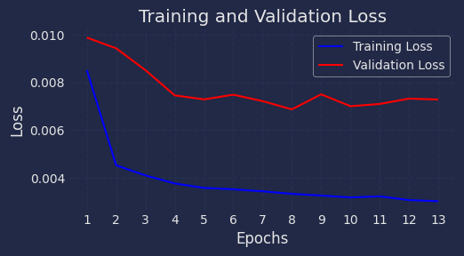

```python
# Seguimiento del entrenamiento y overfitting
# ==============================================================================
fig, ax = plt.subplots(figsize=(5, 2.5))
forecaster.plot_history(ax=ax)
```

Cuando el forecaster modela múltiples series temporales, por defecto, las predicciones se calculan para todas ellas.

```python
# Predicción
# ==============================================================================
predictions = forecaster.predict()
predictions
```

|  | pm2.5 | co | no | o3 |
| --- | --- | --- | --- | --- |
| 2021-04-01 00:00:00 | 13.861774 | 0.116863 | 0.295780 | 32.688377 |
| 2021-04-01 01:00:00 | 13.469391 | 0.111758 | 0.201473 | 34.950497 |
| 2021-04-01 02:00:00 | 13.085013 | 0.110111 | 0.760259 | 33.305016 |
| 2021-04-01 03:00:00 | 12.874469 | 0.112700 | 1.540980 | 30.506596 |
| 2021-04-01 04:00:00 | 12.444548 | 0.108665 | 2.291972 | 30.732586 |

Tamibén se pueden predecir `steps` especificos, siempre y cuado se encuentren dentro del horizonte de predicción definido en el modelo, para series temporales concretas.

```python
# Predicción de steps especificos (1 y 5) para la serie o3
# ==============================================================================
forecaster.predict(steps=[1, 5], levels="o3")
```

|  | o3 |
| --- | --- |
| 2021-04-01 00:00:00 | 32.688377 |
| 2021-04-01 04:00:00 | 30.732586 |

```python
# Backtesting con datos de test
# ==============================================================================
cv = TimeSeriesFold(
        steps=forecaster.max_step,
        initial_train_size=len(data.loc[:end_validation, :]), # Datos de entrenamiento + validación
        refit=False,
    )
metrics, predictions = backtesting_forecaster_multiseries(
    forecaster=forecaster,
    series=data,
    levels=forecaster.levels,
    cv=cv,
    metric="mean_absolute_error",
    verbose=False,
)
```

```
188/188 ━━━━━━━━━━━━━━━━━━━━ 16s 74ms/step - loss: 0.0030 - val_loss: 0.0069
188/188 ━━━━━━━━━━━━━━━━━━━━ 13s 70ms/step - loss: 0.0028 - val_loss: 0.0074
188/188 ━━━━━━━━━━━━━━━━━━━━ 13s 71ms/step - loss: 0.0029 - val_loss: 0.0068
188/188 ━━━━━━━━━━━━━━━━━━━━ 20s 71ms/step - loss: 0.0028 - val_loss: 0.0068
188/188 ━━━━━━━━━━━━━━━━━━━━ 13s 71ms/step - loss: 0.0027 - val_loss: 0.0072
188/188 ━━━━━━━━━━━━━━━━━━━━ 13s 70ms/step - loss: 0.0028 - val_loss: 0.0070
188/188 ━━━━━━━━━━━━━━━━━━━━ 13s 71ms/step - loss: 0.0028 - val_loss: 0.0070
188/188 ━━━━━━━━━━━━━━━━━━━━ 14s 73ms/step - loss: 0.0027 - val_loss: 0.0070
```

```python
# Métricas de error de backtesting para cada serie
# ==============================================================================
metrics
```

|  | levels | mean_absolute_error |
| --- | --- | --- |
| 0 | pm2.5 | 3.708976 |
| 1 | co | 0.025077 |
| 2 | no | 2.843641 |
| 3 | o3 | 11.968777 |
| 4 | average | 4.636617 |
| 5 | weighted_average | 4.636617 |
| 6 | pooling | 4.636617 |

```python
# Gráfico de las predicciones vs valores reales en el conjunto de test
# =============================================================================
fig = px.line(
    data_frame = pd.concat([
                    predictions.melt(ignore_index=False).assign(group="predicciones"),
                    data_test[predictions.columns].melt(ignore_index=False).assign(group="test")
                ]).reset_index().rename(columns={"index": "date_time"}),
    x="date_time",
    y="value",
    facet_row="variable",
    color="group",
    title="Predicciones vs valores reales en el conjunto de test"
)

fig.update_layout(
    title="Predicciones vs valores reales en el conjunto de test",
    width=750,
    height=850,
    margin=dict(l=20, r=20, t=35, b=20),
    legend=dict(
        orientation="h",
        yanchor="top",
        y=1,
        xanchor="left",
        x=0
    )
)

fig.update_yaxes(matches=None)
```

[interactive chart not shown]

Los resultados de backtesting muestran que el modelo es capaz de captar el patrón de las series temporales *pm2.5* y *O3*, pero no el de las series *CO* y *NO*. Esto puede deberse a que las primeras tienen un mayor comportamiento autoregresivo, mientras que los valores futuros de las segundas no parecen depender de los valores pasados.

De nuevo, se observa que el error de backtesting para la serie *O3* es mayor que el obtenido cuando se modelaba únicamente esa serie. Esto puede deberse a que el modelo está intentando modelar múltiples series temporales a la vez, lo que hace que el problema sea más complejo.

## Información de sesión

```python
# Información de la sesión
import session_info
session_info.show(html=False)
```

```
-----
keras               3.5.0
matplotlib          3.9.2
numpy               1.26.4
pandas              2.2.3
plotly              5.24.1
session_info        1.0.0
skforecast          0.14.0
sklearn             1.5.1
tensorflow          2.16.2
-----
IPython             8.27.0
jupyter_client      8.6.3
jupyter_core        5.7.2
notebook            6.4.12
-----
Python 3.12.5 | packaged by Anaconda, Inc. | (main, Sep 12 2024, 18:27:27) [GCC 11.2.0]
Linux-5.15.0-1071-aws-x86_64-with-glibc2.31
-----
Session information updated at 2024-11-10 19:31
```

## Bibliografía

Dive into Deep Learning. Zhang, Aston and Lipton, Zachary C. and Li, Mu and Smola, Alexander J. (2023). Cambridge University Press. https://D2L.ai

© 2024 Codificando Bits https://www.codificandobits.com/blog/redes-neuronales-recurrentes-explicacion-detallada/

Hyndman, R.J., & Athanasopoulos, G. (2021) Forecasting: principles and practice, 3rd edition, OTexts: Melbourne, Australia.

Time Series Analysis and Forecasting with ADAM Ivan Svetunkov.

Joseph, M. (2022). Modern time series forecasting with Python: Explore industry-ready time series forecasting using modern machine learning and Deep Learning. Packt Publishing.

## Instrucciones para citar

**¿Cómo citar este documento?**

Si utilizas este documento o alguna parte de él, te agradecemos que lo cites. ¡Muchas gracias!

Deep Learning para la predicción de series temporales: Redes Neuronales Recurrentes (RNN) y Long Short-Term Memory (LSTM) por Fernando Carazo y Joaquín Amat Rodrigo, disponible bajo licencia Attribution-NonCommercial-ShareAlike 4.0 International en https://www.cienciadedatos.net/documentos/py54-forecasting-con-deep-learning.html

**¿Cómo citar skforecast?**

Zenodo:

Amat Rodrigo, Joaquin, & Escobar Ortiz, Javier. (2023). skforecast (v0.14.0). Zenodo. https://doi.org/10.5281/zenodo.8382788

APA:

Amat Rodrigo, J., & Escobar Ortiz, J. (2023). skforecast (Version 0.14.0) [Computer software]. https://doi.org/10.5281/zenodo.8382788

BibTeX:

@software{skforecast, author = {Amat Rodrigo, Joaquin and Escobar Ortiz, Javier}, title = {skforecast}, version = {0.14.0}, month = {11}, year = {2024}, license = {BSD-3-Clause}, url = {https://skforecast.org/}, doi = {10.5281/zenodo.8382788} }

Este documento creado por Fernando Carazo y Joaquín Amat Rodrigo tiene licencia [Attribution-NonCommercial-ShareAlike 4.0 International](https://creativecommons.org/licenses/by-nc-sa/4.0/).